# hypo

Yuze Yuan

Whether there is a significant difference in the number of male and female suspects. We calculate how many male and female suspects in month, year, then plot the disturbution of number of male and female suspects.

```r
data <- read_csv("../data/full_filter_data.csv")
gender_data <- data %>%
  group_by(year, month, susp_sex) %>%
  summarise(number = n()) %>%
  mutate(susp_sex = as.factor(susp_sex)) %>%
  filter(susp_sex %in% c("F", "M", "U"))
aov_model_1 <- aov(number ~ susp_sex, data = gender_data)

summary(aov_model_1)
```

```
##              Df   Sum Sq  Mean Sq F value Pr(>F)
## susp_sex      2 22482073 11241036     397 <2e-16 ***
## Residuals   456 12910789    28313
## ---
## Signif. codes:  0 '***' 0.001 '**' 0.01 '*' 0.05 '.' 0.1 ' ' 1
```

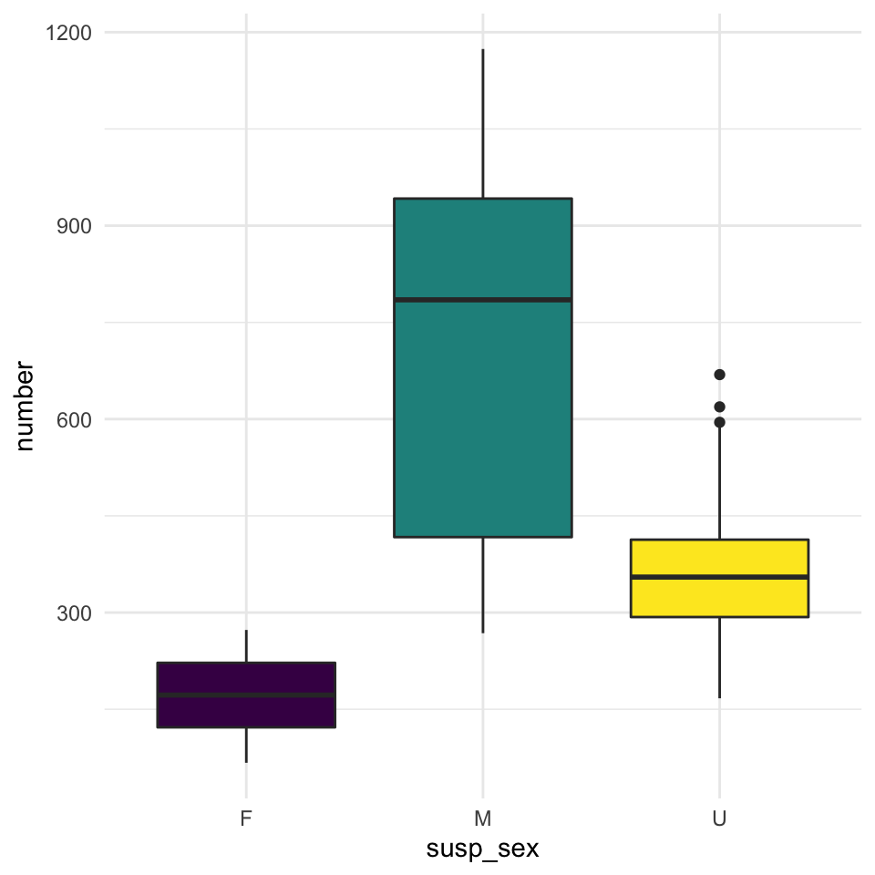

```r
gender_data %>%
  ggplot(aes(x = susp_sex, y = number, fill = susp_sex)) +
  geom_boxplot() +
  guides(fill = "none")
```

* This is a significant difference in the number of male and female suspects. Through the boxplot, we could easily see that male is more likely to be suspencts than females if we consider the unknown.

Whether there is a significant difference in the number of male and female victims. We calculate how many male and female victims in month, year, then plot the disturbution of number of male and female victims. And I also do the same steps for vic_sex include D=Business/Organization, E=PSNY/People of the State of New York.

```r
data <- read_csv("../data/full_filter_data.csv")
gender_data_1 <- data %>%
  group_by(year, month, vic_sex) %>%
  summarise(number = n()) %>%
  mutate(vic_sex = as.factor(vic_sex)) %>%
  filter(vic_sex %in% c("F", "M", "U"))
gender_data_2 <- data %>%
  group_by(year, month, vic_sex) %>%
  summarise(number = n()) %>%
  mutate(vic_sex = as.factor(vic_sex)) %>%
  filter(vic_sex %in% c("F", "M", "D", "E"))
aov_model_1 <- aov(number ~ vic_sex, data = gender_data_1)

summary(aov_model_1)
```

```
##              Df  Sum Sq Mean Sq F value Pr(>F)
## vic_sex       1 1061885 1061885   122.1 <2e-16 ***
## Residuals   304 2644667    8700
## ---
## Signif. codes:  0 '***' 0.001 '**' 0.01 '*' 0.05 '.' 0.1 ' ' 1
```

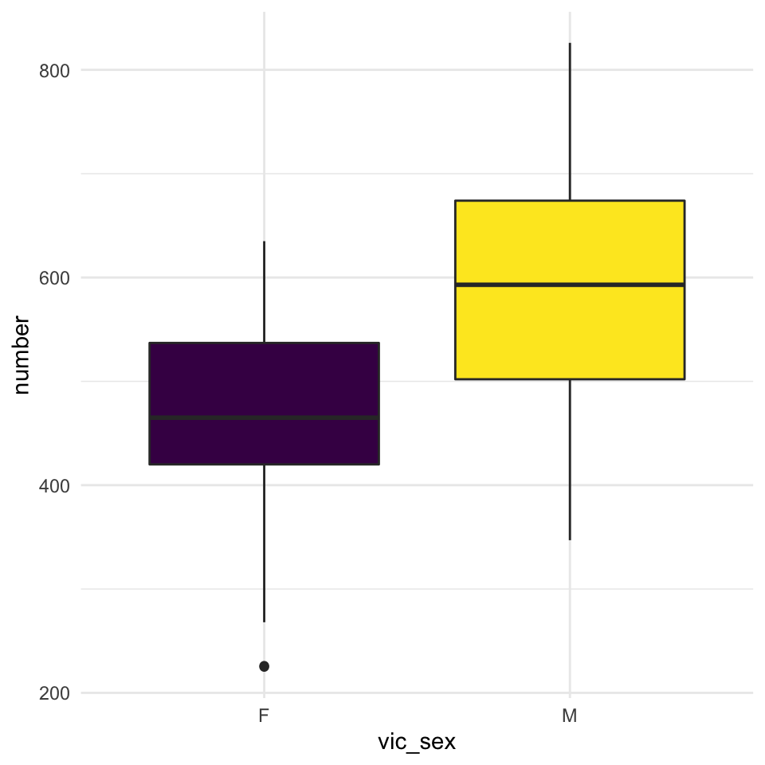

```r
gender_data_1 %>%
  ggplot(aes(x = vic_sex, y = number, fill = vic_sex)) +
  geom_boxplot() +
  guides(fill = "none")
```

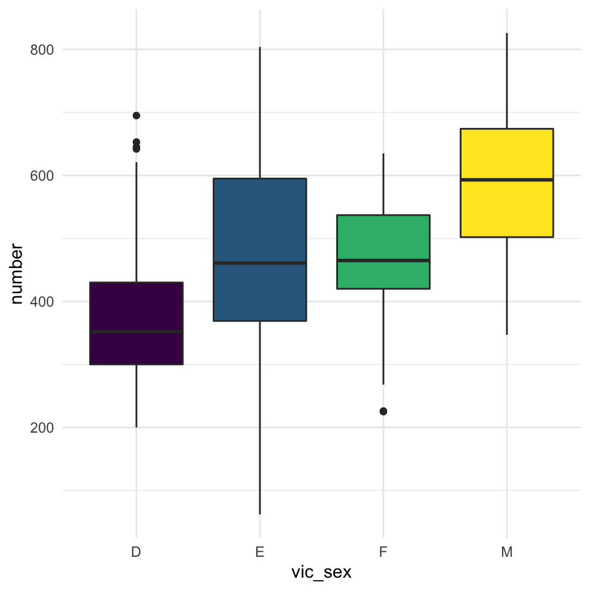

```r
gender_data_2 %>%
  ggplot(aes(x = vic_sex, y = number, fill = vic_sex)) +
  geom_boxplot() +
  guides(fill = "none")
```

* This is a significant difference in the number of male and female suspects. Through the boxplot, we could see that male is more likely to be victims than females.

Whether there is a significant relationship between gender of suspects and sucessful rate.

```r
data <- read_csv("../data/full_filter_data.csv")
gender_data_rate <- data %>%
  filter(susp_sex %in% c("F", "M", "U")) %>%
  mutate(success_fail = ifelse(success_fail == "COMPLETED", 1, 0))

reg_successrate = glm(success_fail ~ susp_sex, family=binomial(link="logit"), data = gender_data_rate)
summary(reg_successrate)
```

```
##
## Call:
## glm(formula = success_fail ~ susp_sex, family = binomial(link = "logit"),
##     data = gender_data_rate)
##
## Deviance Residuals:
##     Min       1Q   Median       3Q      Max
## -2.9660   0.1573   0.2293   0.2293   0.2293
##
## Coefficients:
##             Estimate Std. Error z value Pr(>|z|)
## (Intercept)  4.02709    0.04745  84.864  < 2e-16 ***
## susp_sexM   -0.40201    0.05118  -7.855 4.01e-15 ***
## susp_sexU    0.35921    0.06127   5.863 4.55e-09 ***
## ---
## Signif. codes:  0 '***' 0.001 '**' 0.01 '*' 0.05 '.' 0.1 ' ' 1
##
## (Dispersion parameter for binomial family taken to be 1)
##
##     Null deviance: 38104  on 188240  degrees of freedom
## Residual deviance: 37731  on 188238  degrees of freedom
## AIC: 37737
##
## Number of Fisher Scoring iterations: 7
```

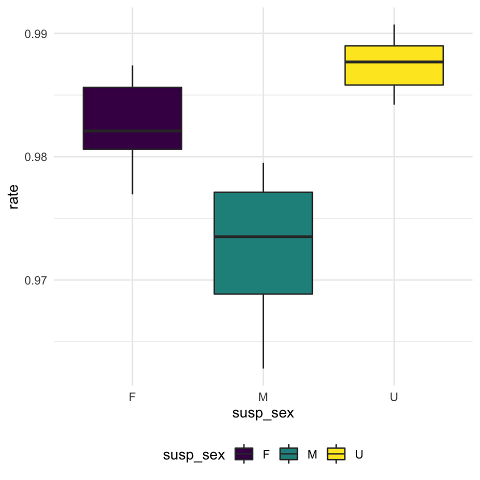

```r
gender_data_rate %>%
  group_by(year, success_fail, susp_sex) %>%
  summarise(number = n()) %>%
  mutate(success_fail = ifelse(success_fail == 1, "COMPLETED", "ATTEMPTED")) %>%
  pivot_wider(
  names_from = "success_fail",
  values_from = "number") %>%
  mutate(total = ATTEMPTED+COMPLETED,
         rate = COMPLETED/total) %>%
  ggplot(aes(x = susp_sex, y = rate, fill = susp_sex)) +
  geom_boxplot()
```

* This is a significant relationship between gender of suspects and sucessful rate. Through the boxplot, we could see that distribution of the successful rate of male suspects is lower than distribution of the successful rate of male suspects.

Whether there is a significant relationship between gender of victims and sucessful rate.

```r
data <- read_csv("../data/full_filter_data.csv")
gender_data_rate_1 <- data %>%
  filter(vic_sex %in% c("F", "M", "D", "E")) %>%
  mutate(success_fail = ifelse(success_fail == "COMPLETED", 1, 0))

reg_successrate_1 = glm(success_fail ~ vic_sex, family=binomial(link="logit"), data = gender_data_rate_1)
summary(reg_successrate_1)
```

```
##
## Call:
## glm(formula = success_fail ~ vic_sex, family = binomial(link = "logit"),
##     data = gender_data_rate_1)
##
## Deviance Residuals:
##     Min       1Q   Median       3Q      Max
## -2.9408   0.1633   0.1809   0.2236   0.2236
##
## Coefficients:
##              Estimate Std. Error z value Pr(>|z|)
## (Intercept)  3.680643   0.027071 135.965   <2e-16 ***
## vic_sexE     0.630044   0.042290  14.898   <2e-16 ***
## vic_sexF     0.424062   0.040067  10.584   <2e-16 ***
## vic_sexM    -0.003994   0.034573  -0.116    0.908
## ---
## Signif. codes:  0 '***' 0.001 '**' 0.01 '*' 0.05 '.' 0.1 ' ' 1
##
## (Dispersion parameter for binomial family taken to be 1)
##
##     Null deviance: 56442  on 290983  degrees of freedom
## Residual deviance: 56046  on 290980  degrees of freedom
## AIC: 56054
##
## Number of Fisher Scoring iterations: 7
```

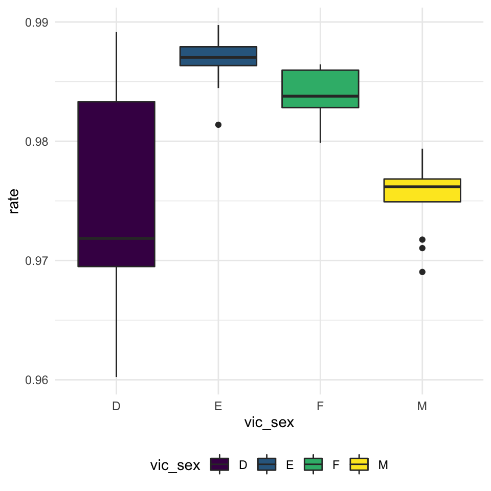

```r
gender_data_rate_1 %>%
  group_by(year, success_fail, vic_sex) %>%
  summarise(number = n()) %>%
  mutate(success_fail = ifelse(success_fail == 1, "COMPLETED", "ATTEMPTED")) %>%
  pivot_wider(
  names_from = "success_fail",
  values_from = "number") %>%
  mutate(total = ATTEMPTED+COMPLETED,
         rate = COMPLETED/total) %>%
  ggplot(aes(x = vic_sex, y = rate, fill = vic_sex)) +
  geom_boxplot()
```

* Through the summary, we could see that male is not significant to the whether victims is succedd or fail. According to the boxplot, we could see that distribution of the successful rate of male victims is also lower than distribution of the successful rate of male victims.